# Practical Machine Learning Course Project

**Background**

Using devices such as Jawbone Up, Nike FuelBand, and Fitbit it is now possible to collect a large amount of data about personal activity relatively inexpensively. These type of devices are part of the quantified self movement - a group of enthusiasts who take measurements about themselves regularly to improve their health, to find patterns in their behavior, or because they are tech geeks. One thing that people regularly do is quantify how much of a particular activity they do, but they rarely quantify how well they do it. In this project, your goal will be to use data from accelerometers on the belt, forearm, arm, and dumbell of 6 participants. They were asked to perform barbell lifts correctly and incorrectly in 5 different ways. More information is available from the website here: http://groupware.les.inf.puc-rio.br/har (see the section on the Weight Lifting Exercise Dataset).

**Data**

The training data for this project are available here:

https://d396qusza40orc.cloudfront.net/predmachlearn/pml-training.csv

The test data are available here:

https://d396qusza40orc.cloudfront.net/predmachlearn/pml-testing.csv

The data for this project come from this source: http://groupware.les.inf.puc-rio.br/har. If you use the document you create for this class for any purpose please cite them as they have been very generous in allowing their data to be used for this kind of assignment.

**Prepare the datasets**

```r
library(caret)
library(randomForest)
library(rpart)
set.seed(2323)
```

Load the training data into a data table and testing data.

```r
library(data.table)
training_data <- read.csv('~/work/data_science/practicle_machine_learning/project/data/pml-training.csv', as.is=TRUE, na.strings=c("NA","#DIV/0!", ""))
testing_data <- read.csv('~/work/data_science/practicle_machine_learning/project/data/pml-testing.csv', as.is=TRUE, na.strings=c("NA","#DIV/0!", ""))
```

**Delete irrelevant columns with all NA values**

```r
training_data <- training_data[,colSums(is.na(training_data)) == 0]
testing_data <-testing_data[,colSums(is.na(testing_data)) == 0]
training_data$classe <- factor(training_data$classe)
```

**Delete irrelevent column for the project**

I found that the first seven column of data setwill not be usefull for the model.

```r
tidy_data  <- training_data[,-c(1:7)]
testing_data <- testing_data[,-c(1:7)]
```

**Cross-validation procedure**

For this project I use 40% of the data to validate my model.

```r
inTrain <- createDataPartition(y = tidy_data$classe, p = 0.6, list = F)
train_data <- tidy_data[inTrain,]
validation_data <- tidy_data[-inTrain,]
```

**Modeling**

I will use random forest for this project. It’s one of the best modeling method.

```r
model <- randomForest(classe ~.,data=train_data)
predict <- predict(model, validation_data)
```

**Cross-validation result**

```r
confusionMatrix(predict, validation_data$classe)
```

```
## Confusion Matrix and Statistics
##
##           Reference
## Prediction    A    B    C    D    E
##          A 2226    9    0    0    0
##          B    5 1505   10    0    0
##          C    0    4 1355    9    0
##          D    0    0    3 1277    5
##          E    1    0    0    0 1437
##
## Overall Statistics
##
##                Accuracy : 0.9941
##                  95% CI : (0.9922, 0.9957)
##     No Information Rate : 0.2845
##     P-Value [Acc > NIR] : < 2.2e-16
##
##                   Kappa : 0.9926
##  Mcnemar's Test P-Value : NA
##
## Statistics by Class:
##
##                      Class: A Class: B Class: C Class: D Class: E
## Sensitivity            0.9973   0.9914   0.9905   0.9930   0.9965
## Specificity            0.9984   0.9976   0.9980   0.9988   0.9998
## Pos Pred Value         0.9960   0.9901   0.9905   0.9938   0.9993
## Neg Pred Value         0.9989   0.9979   0.9980   0.9986   0.9992
## Prevalence             0.2845   0.1935   0.1744   0.1639   0.1838
## Detection Rate         0.2837   0.1918   0.1727   0.1628   0.1832
## Detection Prevalence   0.2849   0.1937   0.1744   0.1638   0.1833
## Balanced Accuracy      0.9979   0.9945   0.9942   0.9959   0.9982
```

**Conclusion**

Random forest give a good result (accuracy is 0.9941). The expected out-of-sample error in about 0.6 %.

The chart bellow give an idea about the importance of each feature for the random forest model.*

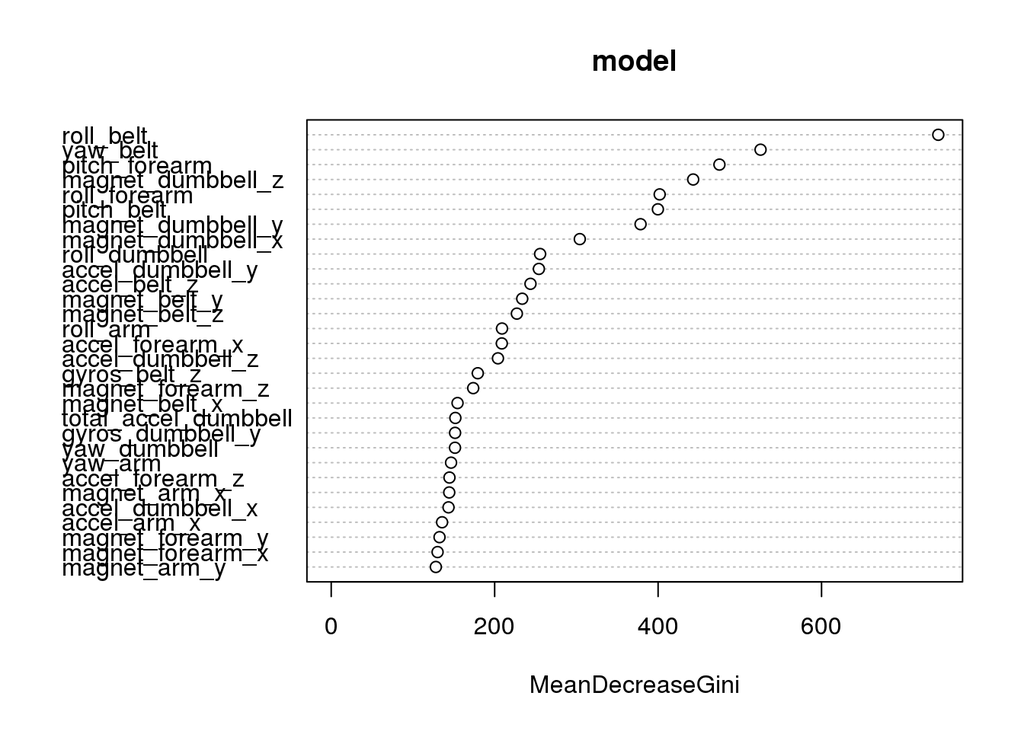

```r
varImpPlot(model)
```

**Final results**

```r
predict_testing_data <- predict(model, testing_data)
predict_testing_data
```

```
##  1  2  3  4  5  6  7  8  9 10 11 12 13 14 15 16 17 18 19 20
##  B  A  B  A  A  E  D  B  A  A  B  C  B  A  E  E  A  B  B  B
## Levels: A B C D E
```

**Write files for submission**

```r
pml_write_files = function(x){
  n = length(x)
  for(i in 1:n){
    filename = paste0("problem_id_",i,".txt")
    write.table(x[i],file=filename,quote=FALSE,row.names=FALSE,col.names=FALSE)
  }
}
setwd("/home/aka/work/data_science/practicle_machine_learning")
pml_write_files(predict_testing_data)
```